# OBIS Querying and Visualization

## Getting started

Installing and loading required R packages

```r
if(!requireNamespace("robis")) {
  install.packages("robis")
}
library(robis)
library(ggplot2)
library(leaflet)
```

Help and issues

- Help: `help(package = "robis")`
- Manual:
  - http://iobis.org/manual/access/
  - http://iobis.org/manual/visualization/
- Issues: https://github.com/iobis/robis/issues

## Occurrence

```r
occurrence(scientificname = NULL, year = NULL, obisid = NULL, aphiaid = NULL,
  groupid = NULL, resourceid = NULL, nodeid = NULL, areaid = NULL, startdate = NULL,
  enddate = NULL, startdepth = NULL, enddepth = NULL, geometry = NULL, qc = NULL,
  fields = NULL, verbose = FALSE)
```

```r
ptevol <- occurrence("Pterois volitans") # red lionfish
```

```
Retrieved 2000 records of 2436 (82%)
Retrieved 2436 records of 2436 (100%)
```

```r
colnames(ptevol)
```

```
 [1] "id"                            "decimalLongitude"              "decimalLatitude"               "depth"
 [5] "institutionCode"               "collectionCode"                "catalogNumber"                 "individualCount"
 [9] "datasetName"                   "phylum"                        "order"                         "family"
[13] "genus"                         "scientificName"                "originalScientificName"        "scientificNameAuthorship"
[17] "obisID"                        "resourceID"                    "species"                       "qc"
[21] "aphiaID"                       "speciesID"                     "scientificNameID"              "class"
[25] "eventDate"                     "yearcollected"                 "basisOfRecord"                 "locality"
[29] "accessRights"                  "collectionID"                  "habitat"                       "higherClassification"
[33] "higherGeography"               "language"                      "locationRemarks"               "modified"
[37] "occurrenceID"                  "recordedBy"                    "recordNumber"                  "rights"
[41] "rightsHolder"                  "specificEpithet"               "stateProvince"                 "type"
[45] "identifiedBy"                  "geodeticDatum"                 "bibliographicCitation"         "minimumDepthInMeters"
[49] "maximumDepthInMeters"          "coordinateUncertaintyInMeters" "eventID"                       "footprintWKT"
[53] "occurrenceRemarks"             "occurrenceStatus"              "waterBody"                     "fieldNumber"
[57] "footprintSRS"                  "references"                    "taxonRank"                     "county"
[61] "lifestage"                     "dynamicProperties"             "dateIdentified"                "vernacularName"
[65] "coordinatePrecision"           "eventTime"                     "associatedMedia"               "datasetID"
[69] "identificationRemarks"         "eventRemarks"                  "ownerInstitutionCode"          "taxonomicStatus"
[73] "island"                        "islandGroup"                   "materialSampleID"              "continent"
```

## Filter by year

```r
occurrence("Pterois volitans", year = 1991,
           fields = c("id", "decimalLongitude", "decimalLatitude", "year"))
```

```
Retrieved 11 records of 11 (100%)
```

```
Following fields where not found and initialized to NA: year
```

| id | decimalLongitude | decimalLatitude | year |
| --- | --- | --- | --- |
| 8317355 | 153.6300 | -27.60000 | NA |
| 10918348 | 55.6000 | -20.86667 | NA |
| 702259173 | 153.6670 | -28.40000 | NA |
| 702263624 | 153.0330 | -30.80000 | NA |
| 702428002 | 145.8500 | -5.16667 | NA |
| 703286139 | 153.6330 | -28.39166 | NA |
| 703690415 | 117.7808 | -19.99333 | NA |
| 703690793 | 116.9650 | -19.76167 | NA |
| 703690899 | 116.7983 | -19.62833 | NA |
| 703691118 | 118.7017 | -18.94334 | NA |

[output cut: 1 more lines]

## Filter by date

```r
occurrence("Pterois volitans", startdate = '1980-03-01', enddate = '1980-10-30',
           fields = c("id", "decimalLongitude", "decimalLatitude", "eventDate"))
```

```
Retrieved 3 records of 3 (100%)
```

| id | decimalLongitude | decimalLatitude | eventDate |
| --- | --- | --- | --- |
| 868932 | 158.1986 | 7.008333 | 1980-09-05 07:00:00 |
| 399697683 | -177.8700 | -29.240000 | 1980-08-06 10:00:00 |
| 702370348 | 116.0660 | -20.283000 | 1980-05-31 10:00:00 |

## Filter by depth

```r
occurrence("Pterois volitans", startdepth = 100, enddepth = 200,
           fields = c("id", "decimalLongitude", "decimalLatitude", "depth"))
```

```
Retrieved 10 records of 10 (100%)
```

| id | decimalLongitude | decimalLatitude | depth |
| --- | --- | --- | --- |
| 703597136 | 127.6836 | -12.391670 | 116.0 |
| 703597267 | 127.9425 | -12.925975 | 100.0 |
| 703597268 | 127.9511 | -12.750695 | 102.5 |
| 703597370 | 134.9856 | -8.843335 | 107.0 |
| 703598330 | 113.3336 | -23.551390 | 120.0 |
| 703690903 | 114.9292 | -20.414165 | 122.5 |
| 703691121 | 117.5433 | -19.020835 | 131.0 |
| 703691470 | 118.1525 | -18.963335 | 119.5 |
| 703691925 | 117.7925 | -19.168335 | 101.5 |
| 732957007 | 120.1400 | 13.880000 | 131.5 |

## Filter by polygon

With http://iobis.org/maptool) we can create a WKT for the Perhentian and Redang Islands and use this to query all occurrences.

```r
islands <- occurrence(geometry =
      paste("POLYGON ((102.68921 6.05862","102.57111 5.95346",
                      "103.07785 5.49980","103.25226 5.62555",
                      "103.07648 5.87970","102.68921 6.05862))",sep=", "))
```

```
Retrieved 532 records of 532 (100%)
```

## Filter by polygon

```r
leafletmap(islands)
```

[interactive chart not shown]

## Visualize data through time

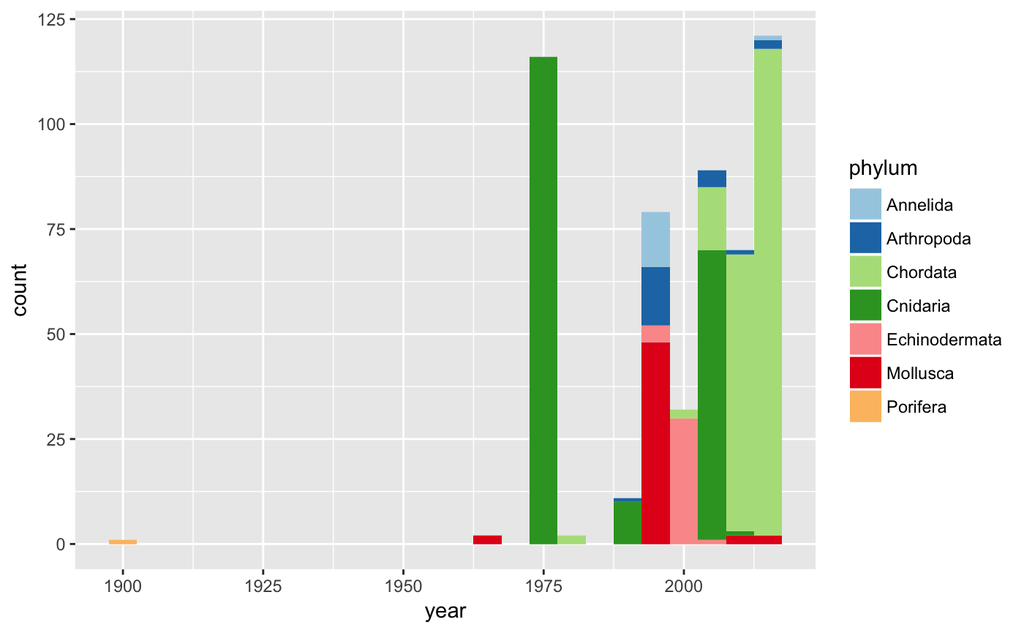

```r
islands$year <- as.numeric(format(as.Date(islands$eventDate), "%Y"))
ggplot(islands[!is.na(islands$year),], aes(x = year, fill = phylum)) +
  geom_histogram(binwidth = 5) +
  scale_fill_brewer(palette = "Paired")
```

## Visualize multiple facets

```r
lag <- occurrence("Lagis", resourceid=c(4312, 222))
```

```
Retrieved 668 records of 668 (100%)
```

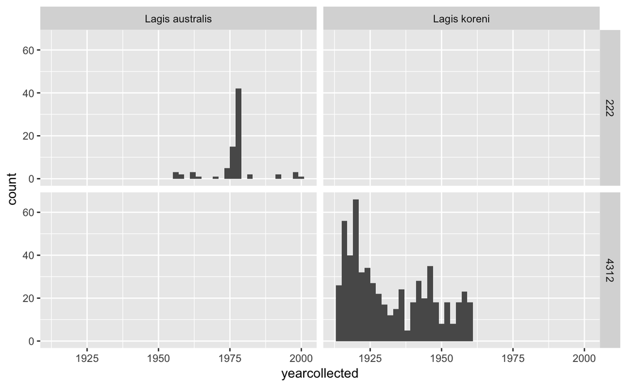

```r
ggplot() +
 geom_histogram(data = lag, aes(x = yearcollected), binwidth = 2) +
 facet_grid(resourceID ~ species)
```

## Filter by dataset

```r
datasets <- dataset(q="Adriatic-INTERREG")
```

```
Retrieved 6 records of 6 (100%)
```

```r
datasets$name
```

```
[1] "Meiobenthos North Adriatic-INTERREG-FVG-Projects"  "Mesozooplankton North Adriatic-INTERREG Project"
[3] "Microzooplankton North Adriatic-INTERREG Project"  "Microphytobenthos North Adriatic-INTERREG Project"
[5] "Macrobenthos North Adriatic-INTERREG-FVG Project"  "Phytoplankton North Adriatic-INTERREG-FVG Project"
```

## Filter by dataset

```r
occ <- occurrence(resourceid = datasets$id, year = 1998,
           fields = c("id", "decimalLongitude", "decimalLatitude", "resourceID"))
```

```
Retrieved 1553 records of 1553 (100%)
```

```r
head(occ)
```

|  | id | decimalLongitude | decimalLatitude | resourceID |
| --- | --- | --- | --- | --- |
| 1 | 719561828 | 13.56467 | 45.69350 | 3494 |
| 2 | 719561980 | 13.59617 | 45.66383 | 3494 |
| 3 | 719561996 | 13.56467 | 45.69350 | 3494 |
| 4 | 719561997 | 13.56467 | 45.69350 | 3494 |
| 5 | 719561998 | 13.56467 | 45.69350 | 3494 |
| 6 | 719561999 | 13.56467 | 45.69350 | 3494 |

## Filter by quality control

Vandepitte L., Bosch S., Tyberghein L., Waumans F., Vanhoorne B., Hernandez F., De Clerck O., & Mees J. (2015) **Fishing for data and sorting the catch: assessing the data quality, completeness and fitness for use of data in marine biogeographic databases**. Database, 2015. http://dx.doi.org/10.1093/database/bau125

```r
?qcflags
```

Categories of quality control flags:

- Data format
- Taxonomy
- Completeness
- Geography
- Depth
- Outliers

## Some filters: quality control

- 3. Taxonomy: is the taxon level genus or lower?
- 4. Geography (lat/lon): are the latitude/longitude values different from zero?
- 5. Geography (lat/lon): are the latitude/longitude values within their possible boundaries? (world coordinates)
- 7. Completeness (date/time): is the sampling year (start/end) completed and valid?

```r
qc3457 <- occurrence(resourceid = datasets$id, qc = c(3,4,5,7), year = 1998)
```

```
Retrieved 1005 records of 1005 (100%)
```

## Visualize QC

- 28. Species outliers (geography): is the observation within three IQRs from the first & third quartile distance to the geographic centroid of this taxon?

```r
acistu <- occurrence("Acipenser sturio")
```

```
Retrieved 66 records of 66 (100%)
```

```r
acistu$qcnum <- qcflags(acistu$qc, c(28))
colors <- c("#ee3300", "#86b300")[acistu$qcnum + 1]
popup <- paste0(acistu$datasetName, "<br/>", acistu$catalogNumber,
                "<br/><a href=\"http://www.iobis.org/explore/#/dataset/",
                acistu$resourceID, "\">OBIS dataset page</a>")
```

## Visualize QC

```r
leaflet() %>% addProviderTiles("CartoDB.Positron") %>%
  addCircleMarkers(
    popup = popup, radius = 3.5, weight = 0, fillColor = colors, fillOpacity = 1,
    lat = acistu$decimalLatitude, lng = acistu$decimalLongitude)
```

[interactive chart not shown]

## Visualize QC

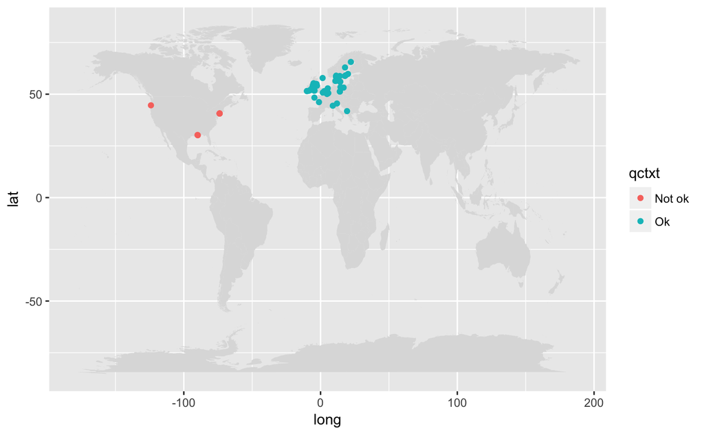

```r
acistu$qctxt <- c("Not ok", "Ok")[acistu$qcnum + 1]
ggplot() +
  geom_polygon(data=map_data("world"),aes(x=long,y=lat,group=group),fill="#dddddd")+
  geom_point(data=acistu, aes(x=decimalLongitude, y=decimalLatitude, color=qctxt))
```

## Visualize environmental data

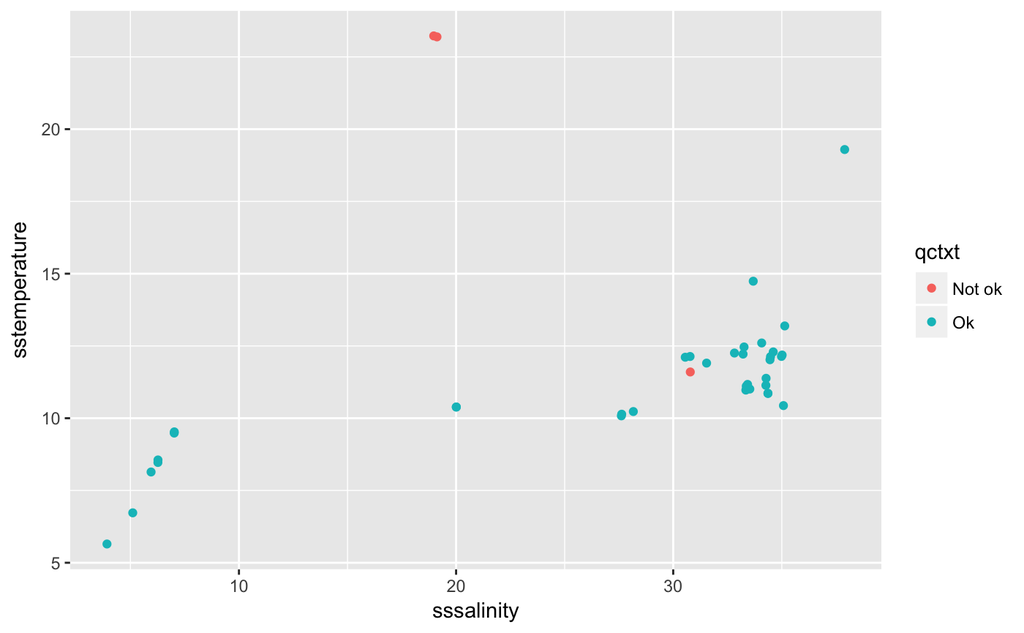

```r
env <- obistools::lookup_xy(acistu)
envacistu <- cbind(acistu[complete.cases(env),], env[complete.cases(env),])
ggplot(envacistu, aes(x=sssalinity, y=sstemperature, color=qctxt)) +
  geom_point()
```

## *checklist*: Generate checklists

```r
checklist(scientificname = NULL, year = NULL, obisid = NULL, aphiaid = NULL,
  groupid = NULL, resourceid = NULL, areaid = NULL, startdate = NULL, enddate = NULL,
  startdepth = NULL, enddepth = NULL, geometry = NULL, qc = NULL, fields = NULL,
  verbose = FALSE)
```

## *checklist*: Generate checklists

```r
checklist(year=1800)[1:3,]
```

```
Retrieved 16 records of 16 (100%)
```

|  | id | valid_id | parent_id | rank_name | tname | tauthor | worms_id | redlist | status | records | datasets | phylum | order | family | genus | species | class |
| --- | --- | --- | --- | --- | --- | --- | --- | --- | --- | --- | --- | --- | --- | --- | --- | --- | --- |
| 1 | 402913 | 402913 | 402912 | Species | Anguilla anguilla | (Linnaeus, 1758) | 126281 | TRUE | CR | 4 | 1 | Chordata | Anguilliformes | Anguillidae | Anguilla | Anguilla anguilla | Actinopterygii |
| 2 | 408772 | 408772 | 408771 | Subspecies | Auxis thazard thazard | (Lacepède, 1800) | 293552 | NA | NA | 1 | 1 | Chordata | Perciformes | Scombridae | Auxis | Auxis thazard | Actinopterygii |
| 3 | 424201 | 424201 | 424193 | Species | Clupea harengus | Linnaeus, 1758 | 126417 | TRUE | LC | 2 | 1 | Chordata | Clupeiformes | Clupeidae | Clupea | Clupea harengus | Actinopterygii |

## *dataset*: Dataset metadata

```r
dataset(id = NULL, scientificname = NULL, q = NULL, obisid = NULL,
        aphiaid = NULL, groupid = NULL, areaid = NULL, nodeid = NULL,
        startdate = NULL, enddate = NULL, startdepth = NULL, enddepth = NULL,
        geometry = NULL, verbose = FALSE)
```

## *dataset*: Dataset metadata

```r
as.data.frame(dataset(id = 1))
```

```
Retrieved 1 records of 1 (100%)
```

| id | digirname | website | citation | species_cnt | taxon_cnt | record_cnt | imis_dasid | name |
| --- | --- | --- | --- | --- | --- | --- | --- | --- |
| 1 | BATS | http://www.vims.edu/bio/zooplankton/BATS | Steinberg, D.K. and L.P. Madin (2003) Zooplankton Census. Bermuda Atlantic Time-series Study | 23 | 25 | 635 | 3802 | Bermuda Atlantic Time-series Study Zooplankton Census |

## *taxon* and *taxon_common*

```r
taxon(obisid = NULL, aphiaid = NULL, scientificname = NULL, verbose = FALSE)
taxon_common(obisid, verbose = FALSE)
```

```r
tax <- taxon(scientificname = "Pterois volitans")
tax
```

|  | id | valid_id | parent_id | rank_name | tname | tauthor | worms_id | gisd | records | datasets | phylum | order | family | genus | species | class |
| --- | --- | --- | --- | --- | --- | --- | --- | --- | --- | --- | --- | --- | --- | --- | --- | --- |
| 1 | 501083 | 501083 | 501069 | Species | Pterois volitans | (Linnaeus, 1758) | 159559 | TRUE | 2436 | 51 | Chordata | Scorpaeniformes | Scorpaenidae | Pterois | Pterois volitans | Actinopterygii |

```r
taxon_common(tax$valid_id)
```

|  | name | language |
| --- | --- | --- |
| 1 | lionfish | English |
| 2 | red lionfish | English |
| 3 | turkeyfish | English |

## *area*: OBIS areas

```r
head(area())
```

```
Retrieved 535 records of 535 (100%)
```

|  | id | name | type |
| --- | --- | --- | --- |
| 1 | 309 | The Sundarbans | prot |
| 2 | 24 | Bosnia and Herzegovina | eez |
| 3 | 322 | Shiretoko | prot |
| 4 | 478 | EBSA No 2: Ua puakaoa seamounts | ebsa |
| 5 | 371 | Rivercess and Sinoe Sea Turtle Breeding Ground (Liberia) | ebsa |
| 6 | 127 | Malaysia | eez |

## *node*: OBIS nodes

```r
node()[1:5,]
```

```
Retrieved 29 records of 29 (100%)
```

|  | id | description | name | url | theme |
| --- | --- | --- | --- | --- | --- |
| 1 | 1 | OBIS Argentina | AR-OBIS | http://arobis.cenpat-conicet.gob.ar/ | Argentina |
| 2 | 2 | AfrOBIS | AfrOBIS | http://afrobis.csir.co.za/ | Sub-Saharan (S-Africa) |
| 3 | 3 | Antarctic OBIS | Antarctic OBIS | http://www.scarmarbin.be/ | Antarctica |
| 4 | 15 | ArCOD | ArCOD | http://www.arcodiv.org/ | Arctic |
| 5 | 28 | Arctic OBIS | Arctic OBIS | NA | Arctic |

## *group*: Taxonomic groups

```r
head(group())
```

```
Retrieved 85 records of 85 (100%)
```

|  | id | name |
| --- | --- | --- |
| 1 | 1 | Acarina |
| 2 | 2 | Amoebozoa |
| 3 | 3 | Amphipoda |
| 4 | 4 | Apusozoa |
| 5 | 5 | Ascidiacea |
| 6 | 6 | Aves |

# In Python

## Getting started

Installation

```r
# from pypi
pip install pyobis

# dev
pip install git+git://github.com/sckott/pyobis.git#egg=pyobis
```

Help and issues: https://github.com/sckott/pyobis

## Occurrence

```r
from pyobis import occurrences
occurrences.search(scientificname = 'Mola mola')
occurrences.search(scientificname = 'Mola mola', offset=0, limit=10)
occurrences.search(geometry='POLYGON((30.1 10.1, 10 20, 20 40, 40 40, 30.1 10.1))',
                   limit=20)
occurrences.search(aphiaid=key, year="2013", limit=20)
```

```r
res = occurrences.download(year = 2001, scientificname = 'Orcinus')
res.uuid
res.status()
res.fetch()
```

## Other methods

- checklist - Create a checklist for a geometry, timeperiod, taxonomic group, …
- taxa - Lookup taxonomic names
- groups - List of taxonomic groups
- resources - Lookup datasets metadata
- nodes - Lookup OBIS nodes metadata

# API

## Documentation

REST API with same methods as implemented in *robis*.

https://github.com/iobis/api-docs

# Web

## Explore Portal

http://iobis.org/

## Mapper

http://iobis.org/mapper2